# Factors Affecting Average Life Expectancy

Project 1

490294583, 480438353, 480188609, 490404001 | Friday 8am Carslaw Computational Lab 610/611 N.James

University of Sydney | DATA1001 | MARCH 2019

# 1 Executive Summary

# 2 Initial Data Analysis (IDA)

```r
setwd("C:/Users/Lewis/Docs/DATA1001files/Data")

life = read.csv("expectancy.csv")
```

Showing the dimentions of the data

```r
dim(life)
```

```
## [1] 2938   22
```

Showing the class of the data

```r
class(life)
```

```
## [1] "data.frame"
```

Showing the structure of the data

```r
str(life)
```

```
## 'data.frame':    2938 obs. of  22 variables:
##  $ Country                        : Factor w/ 193 levels "Afghanistan",..: 1 1 1 1 1 1 1 1 1 1 ...
##  $ Year                           : int  2015 2014 2013 2012 2011 2010 2009 2008 2007 2006 ...
##  $ Status                         : Factor w/ 2 levels "Developed","Developing": 2 2 2 2 2 2 2 2 2 2 ...
##  $ Life.expectancy                : num  65 59.9 59.9 59.5 59.2 58.8 58.6 58.1 57.5 57.3 ...
##  $ Adult.Mortality                : int  263 271 268 272 275 279 281 287 295 295 ...
##  $ infant.deaths                  : int  62 64 66 69 71 74 77 80 82 84 ...
##  $ Alcohol                        : num  0.01 0.01 0.01 0.01 0.01 0.01 0.01 0.03 0.02 0.03 ...
##  $ percentage.expenditure         : num  71.3 73.5 73.2 78.2 7.1 ...
##  $ Hepatitis.B                    : int  65 62 64 67 68 66 63 64 63 64 ...
##  $ Measles                        : int  1154 492 430 2787 3013 1989 2861 1599 1141 1990 ...
##  $ BMI                            : num  19.1 18.6 18.1 17.6 17.2 16.7 16.2 15.7 15.2 14.7 ...
##  $ under.five.deaths              : int  83 86 89 93 97 102 106 110 113 116 ...
##  $ Polio                          : int  6 58 62 67 68 66 63 64 63 58 ...
##  $ Total.expenditure              : num  8.16 8.18 8.13 8.52 7.87 9.2 9.42 8.33 6.73 7.43 ...
##  $ Diphtheria                     : int  65 62 64 67 68 66 63 64 63 58 ...
##  $ HIV.AIDS                       : num  0.1 0.1 0.1 0.1 0.1 0.1 0.1 0.1 0.1 0.1 ...
##  $ GDP                            : num  584.3 612.7 631.7 670 63.5 ...
##  $ Population                     : num  33736494 327582 31731688 3696958 2978599 ...
##  $ thinness..1.19.years           : num  17.2 17.5 17.7 17.9 18.2 18.4 18.6 18.8 19 19.2 ...
##  $ thinness.5.9.years             : num  17.3 17.5 17.7 18 18.2 18.4 18.7 18.9 19.1 19.3 ...
##  $ Income.composition.of.resources: num  0.479 0.476 0.47 0.463 0.454 0.448 0.434 0.433 0.415 0.405 ...
##  $ Schooling                      : num  10.1 10 9.9 9.8 9.5 9.2 8.9 8.7 8.4 8.1 ...
```

## 2.1 Summary

Stakeholders relating to this data are governments and non-governmental health organizations such as the WHO and the World Bank. It relates to governments as it shows the life expectancy of their countries and contributing factors which can be analyzed in order to form policies such as increased healthcare spending or length of schooling years. Global organizations can also use this data to target certain countries that require healthcare aid.

Some basic knowledge required when analysing the data includes an understanding of what each variable means and understanding the actual definition of life expectancy: “By definition, life expectancy is based on an estimate of the average age that members of a particular population group will be when they die.” (Ortiz-Ospina, 2017) This implies that the value for average life expectancy is an estimate and is not an exact value representing an entire population. Hence this value may not always be accurate, especially when you consider the lack of ability of some developing countries to gather population data. An example of a variable that needs to be understood is the percentage.expenditure variable which represents the percentage of a country’s GDP per capita that was spent on healthcare. This requires the knowledge that GDP per capita is a value representing the total economic activity in the country divided by the number of people in the country. (Amadeo, 2019) This knowledge allows for a better understanding of this variable in that it is a factor affected by both the total income of a country’s economy and its population.

An initial look into this dataset is given by the following graph of the world average life expectancy from 2000 to 2014.

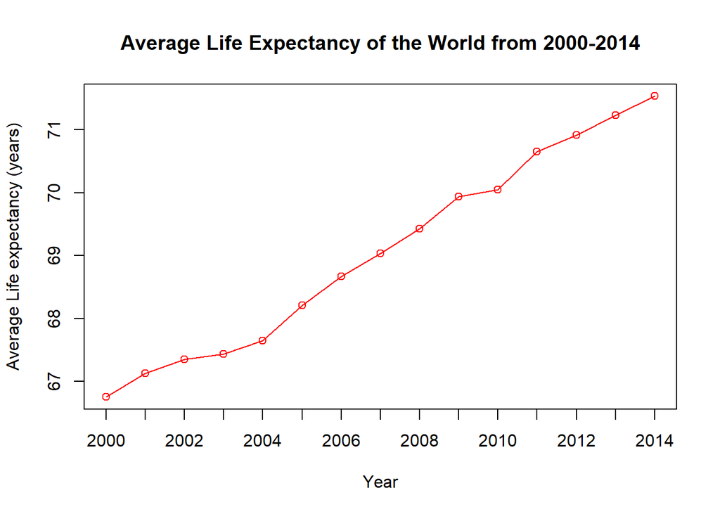

```r
average_2000 = mean(life$Life.expectancy[life$Year=="2000"], na.rm=TRUE)
average_2001 = mean(life$Life.expectancy[life$Year=="2001"], na.rm=TRUE)
average_2002 = mean(life$Life.expectancy[life$Year=="2002"], na.rm=TRUE)
average_2003 = mean(life$Life.expectancy[life$Year=="2003"], na.rm=TRUE)
average_2004 = mean(life$Life.expectancy[life$Year=="2004"], na.rm=TRUE)
average_2005 = mean(life$Life.expectancy[life$Year=="2005"], na.rm=TRUE)
average_2006 = mean(life$Life.expectancy[life$Year=="2006"], na.rm=TRUE)
average_2007 = mean(life$Life.expectancy[life$Year=="2007"], na.rm=TRUE)
average_2008 = mean(life$Life.expectancy[life$Year=="2008"], na.rm=TRUE)
average_2009 = mean(life$Life.expectancy[life$Year=="2009"], na.rm=TRUE)
average_2010 = mean(life$Life.expectancy[life$Year=="2010"], na.rm=TRUE)
average_2011 = mean(life$Life.expectancy[life$Year=="2011"], na.rm=TRUE)
average_2012 = mean(life$Life.expectancy[life$Year=="2012"], na.rm=TRUE)
average_2013 = mean(life$Life.expectancy[life$Year=="2013"], na.rm=TRUE)
average_2014 = mean(life$Life.expectancy[life$Year=="2014"], na.rm=TRUE)
year_averages = c(average_2000,average_2001,average_2002,average_2003,average_2004,average_2005,average_2006,average_2007,average_2008,average_2009,average_2010,average_2011,average_2012,average_2013,average_2014)

labels = c("2000","2001","2002","2003","2004","2005","2006","2007","2008","2009","2010","2011","2012","2013","2014","2015")
hat = c(1,2,3,4,5,6,7,8,9,10,11,12,13,14,15,16)

plot(year_averages, type = 'o', xaxt = 'n', col = 'red', xlab = 'Year', ylab = 'Average Life expectancy (years)',main = 'Average Life Expectancy of the World from 2000-2014')
axis(side=1, at=hat, labels=labels)
```

# 3 Research Question 1

## 3.1 Which of the variables can we be sure are actually having an effect on predicted life expectancy?

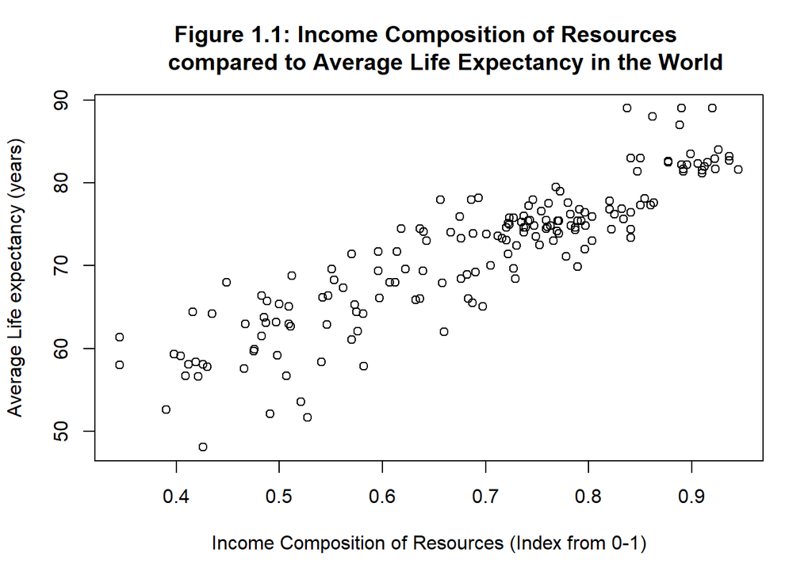

```r
plot(life$Income.composition.of.resources[life$Year == '2014'], life$Life.expectancy[life$Year == '2014'], xlab = "Income Composition of Resources (Index from 0-1)", ylab = 'Average Life expectancy (years)',main = 'Figure 1.1: Income Composition of Resources
     compared to Average Life Expectancy in the World')
```

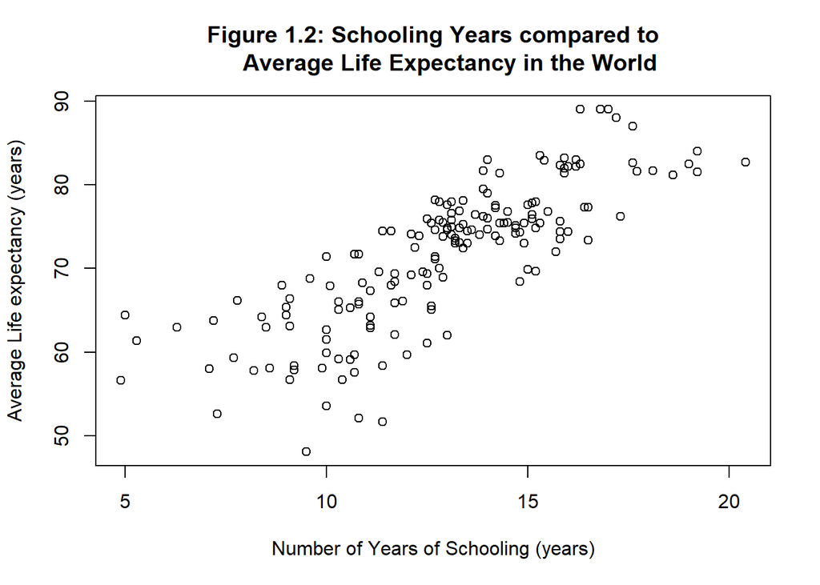

```r
plot(life$Schooling[life$Year == '2014'], life$Life.expectancy[life$Year == '2014'], xlab = "Number of Years of Schooling (years)", ylab = 'Average Life expectancy (years)',main = 'Figure 1.2: Schooling Years compared to
     Average Life Expectancy in the World')
```

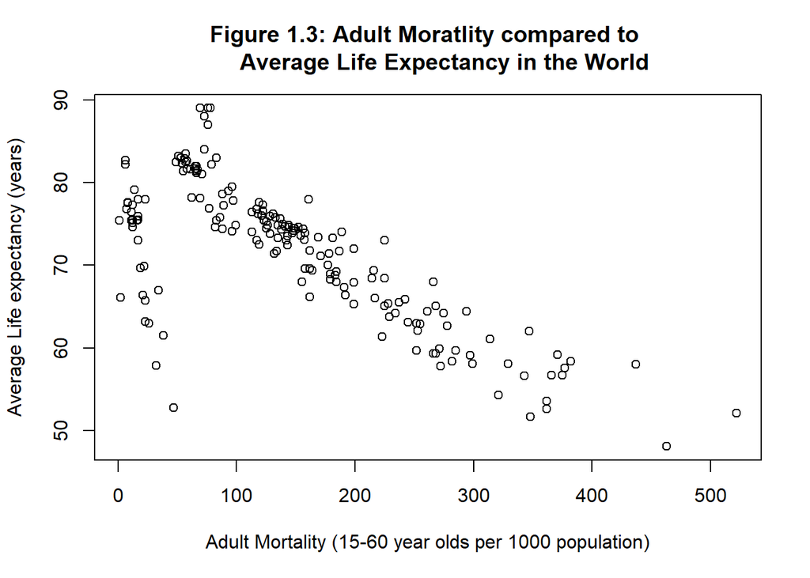

```r
plot(life$Adult.Mortality[life$Year == '2014'], life$Life.expectancy[life$Year == '2014'], xlab = "Adult Mortality (15-60 year olds per 1000 population)", ylab = 'Average Life expectancy (years)',main = 'Figure 1.3: Adult Moratlity compared to
     Average Life Expectancy in the World')
```

Over the first fifteen years of the 21st century, there has been an increase in average life expectancy worldwide. This has mainly been driven by improvements made in several variables which affect life expectancy. We determined which variables have a discernible effect using scatterplots in order to determine whether there was correlation between a given variable and life expectancy. Using 2014 as a sample, we observed for instance that countries with greater percentage expenditure on healthcare also had higher life expectancies. With this method, we observed that better education (more years spent in school), an increase in GNI per capita and percentage expenditure on healthcare have a correlation with higher life expectancy over the past decade and a half.The Thinness of children aged 5-9 and 1-19, under 5 deaths, infant mortality, BMI and adult mortality all had a negative correlation. Given this information, we had to determine which variables which correlated had an actual effect on life expectancy and which did not have an effect on life expectancy but correlated because countries with high life expectancies were likely to also have good results for the variable. The latter was the conclusion we came to for average schooling years, which is unlikely to directly affect life expectancy but is usually found in countries with high life expectancies. The other variables, including population and total expenditure on healthcare, we concluded did not directly affect average life expectancy.

# 4 Research Question 2

## 4.1 How is life expectancy affected by consumption of alcohol and is the relationship positive or negative?

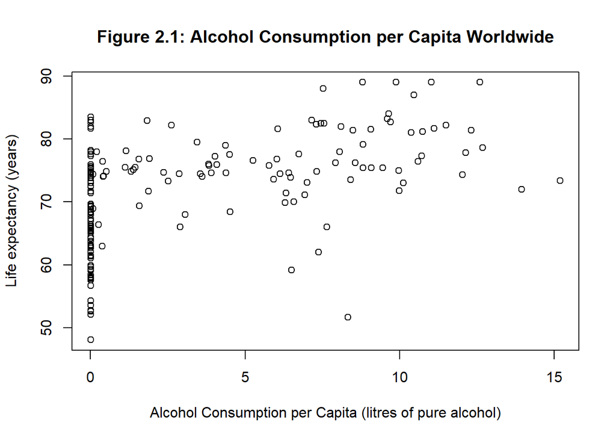

```r
plot(life$Alcohol[life$Year == '2014'], life$Life.expectancy[life$Year == '2014'], xlab = "Alcohol Consumption per Capita (litres of pure alcohol)", ylab = 'Life expectancy (years)',main = 'Figure 2.1: Alcohol Consumption per Capita Worldwide')
```

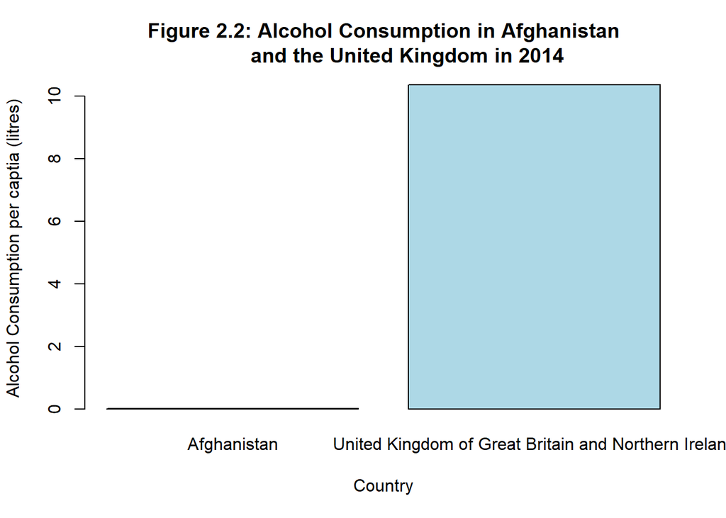

```r
barplot1 = life[which((life$Year == 2014 & life$Country == 'Afghanistan') | (life$Year == 2014 & life$Country == 'United Kingdom of Great Britain and Northern Ireland')), ]

barplot(barplot1$Alcohol, names.arg = c('Afghanistan','United Kingdom of Great Britain and Northern Ireland'), col = 'lightblue', xlab = 'Country', ylab = 'Alcohol Consumption per captia (litres)', main = 'Figure 2.2: Alcohol Consumption in Afghanistan
        and the United Kingdom in 2014')
```

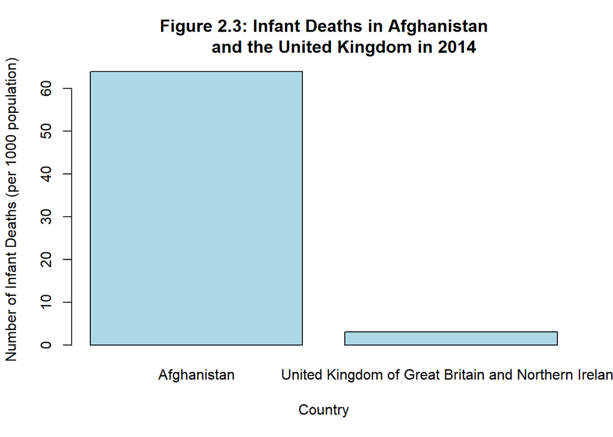

```r
barplot2 = life[which((life$Year == 2014 & life$Country == 'Afghanistan') | (life$Year == 2014 & life$Country == 'United Kingdom of Great Britain and Northern Ireland')), ]

barplot(barplot2$infant.deaths, names.arg = c('Afghanistan', 'United Kingdom of Great Britain and Northern Ireland'), col = 'lightblue', xlab = 'Country', ylab = 'Number of Infant Deaths (per 1000 population)', main = 'Figure 2.3: Infant Deaths in Afghanistan
        and the United Kingdom in 2014')
```

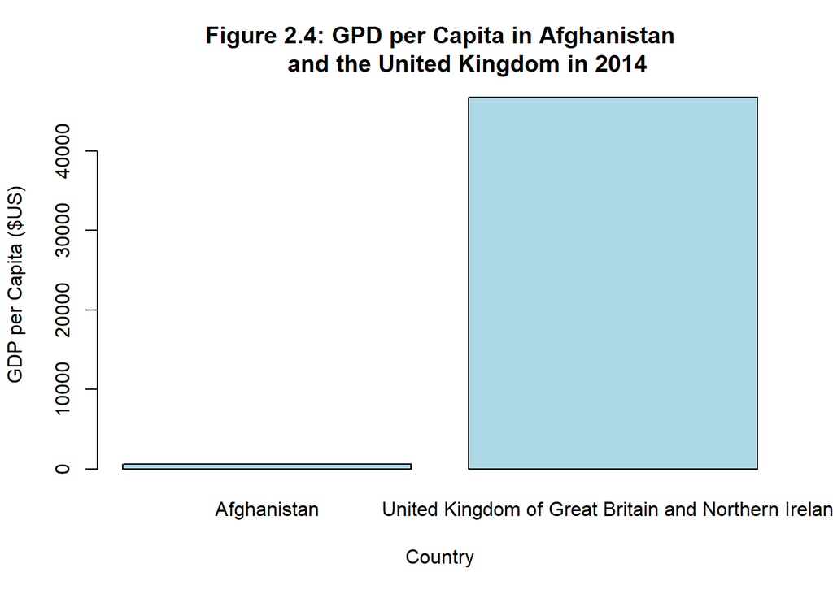

```r
barplot3 = life[which((life$Year == 2014 & life$Country == 'Afghanistan') | (life$Year == 2014 & life$Country == 'United Kingdom of Great Britain and Northern Ireland')), ]

barplot(barplot3$GDP, names.arg = c('Afghanistan','United Kingdom of Great Britain and Northern Ireland'), col = 'lightblue', xlab = 'Country', ylab = 'GDP per Capita ($US)', main = 'Figure 2.4: GPD per Capita in Afghanistan
        and the United Kingdom in 2014')
```

Given the negative health effects of excessive alcohol consumption, our initial hypothesis was that there would be a negative correlation worldwide between life expectancy and alcohol consumption. However, it seems that average alcohol consumption has no negative impact, and if anything Figure 2.1 indicates a slight correlation between alcohol consumption and life expectancy. According to Figure 2.1, life expectancy remains mostly constant regardless of alcohol consumption, with some countries with the highest alcohol consumption having very high life expectancy. This can be explained partly by understanding that while alcohol consumption can cause death (when excessive), the number is relatively small. According to the Australian Bureau of Statistics 0.85% of deaths in Australia are directly attributed to alcohol, although the number rises if you count all deaths where alcohol was involved (2.6%). (Australian Bureau of Statistics, 2018) Another reason is that several countries abstain almost completely from drinking alcohol (mainly Islamic countries in Africa/Middle East), and are nonetheless affected by various other factors which lower life expectancy. These countries account for the large concentration of subjects clumped together to the left of the graph. The various religious and cultural reasons which prevent certain countries from high alcohol consumption do not apply in Europe or North America, where other factors are more favourable. This is the reason for the slight correlation in Figure 2.1, not any health benefit that alcohol consumption has. Observing Figures 2.2, 2.3 and 2.4, Afghanistan consumes far less alcohol than the UK but has a lower life expectancy due to factors like infant mortality.

# 5 Research Question 3

## 5.1 Would it be effective for countries with lower life expectancies (under 65) to attempt to improve their average lifespan by increasing the percentage expenditure on healthcare?

Assuming that a government’s healthcare’s expenditure actually iprove’s the population’s health, we hypothesised that countries with a life expectancy of less than 65 should increase their expenditure in order to improve their life expectancy. There is generally a positive correlation between increasing expenditure on healthcare and increased life expectancy. While this does not imply direct causation between expenditure on healthcare and increased life expectancy, it serves to show that there may be merit to increasing healthcare spending.

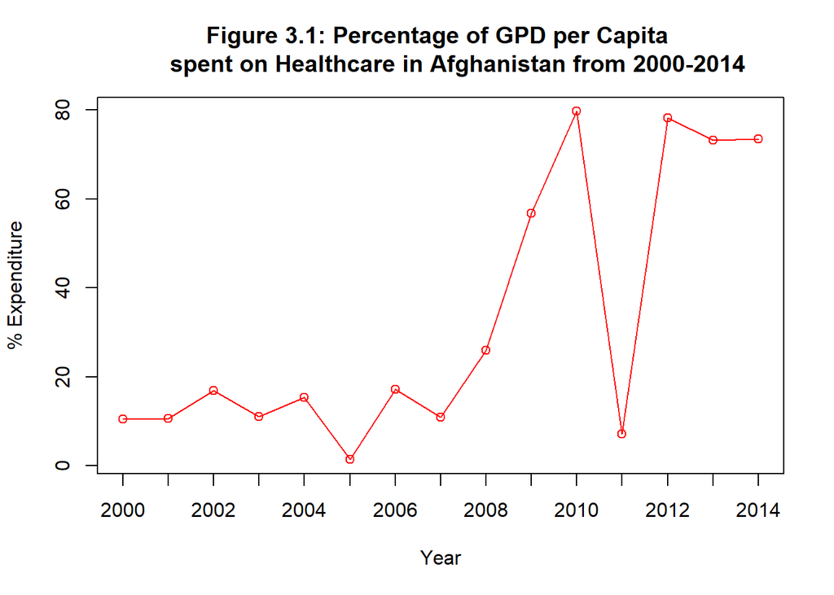

```r
afghan_life = rev(c(life$Life.expectancy[life$Country=="Afghanistan"]))
afghan_life = afghan_life[-(16)]

afghan_expend = rev(c(life$percentage.expenditure[life$Country=="Afghanistan"]))
afghan_expend = afghan_expend[-(16)]

plot(afghan_expend, type = 'o', xaxt= 'n', col = 'red', xlab = "Year", ylab = '% Expenditure', main = 'Figure 3.1: Percentage of GPD per Capita
     spent on Healthcare in Afghanistan from 2000-2014')
axis(side=1, at=hat, labels=labels)
```

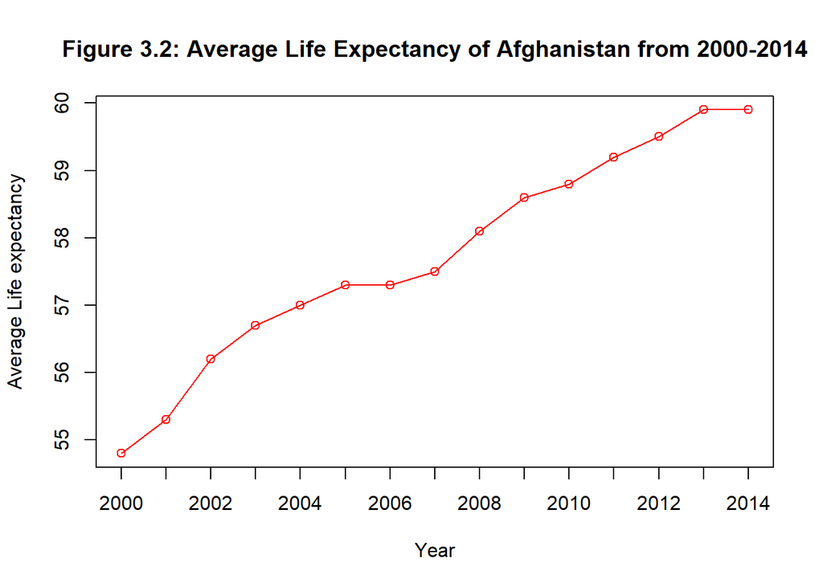

```r
plot(afghan_life, type = 'o', xaxt= 'n', col = 'red', xlab = "Year", ylab = 'Average Life expectancy', main = 'Figure 3.2: Average Life Expectancy of Afghanistan from 2000-2014')
axis(side=1, at=hat, labels=labels)
```

This can be seen in the two line graphs above for Afghanistan (a developing country) where life expectancy increased from 54.8 to 59.9 over 14 years and healthcare expenditure also had a positive trend increasing from 10.4% of GPD per capita to 73.5% of GDP per capita. A similar trend can also be seen in the graphs for Benin, albeit with not as strong a correlation.

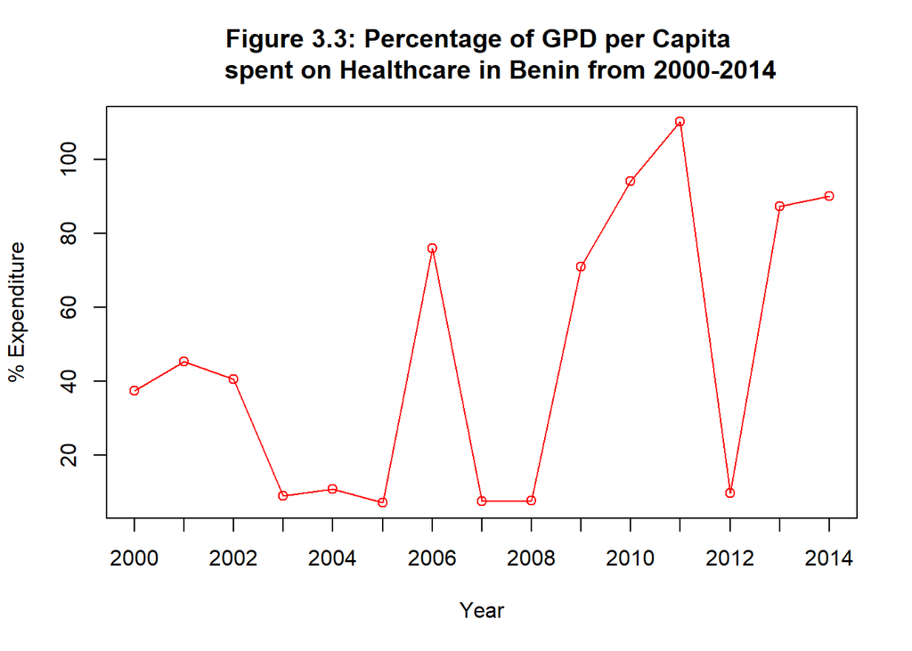

```r
benin_life = rev(c(life$Life.expectancy[life$Country=="Benin"]))
benin_life = benin_life[-(16)]

benin_expend = rev(c(life$percentage.expenditure[life$Country=="Benin"]))
benin_expend = benin_expend[-(16)]

plot(benin_expend, type = 'o', xaxt= 'n', col = 'red', xlab = "Year", ylab = '% Expenditure', main = 'Figure 3.3: Percentage of GPD per Capita
     spent on Healthcare in Benin from 2000-2014')
axis(side=1, at=hat, labels=labels)
```

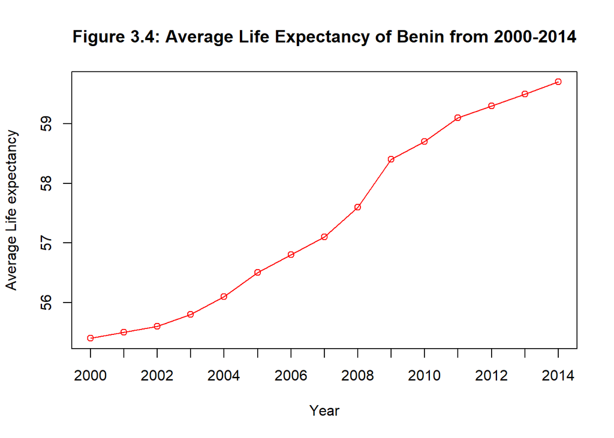

```r
plot(benin_life, type = 'o', xaxt= 'n', col = 'red', xlab = "Year", ylab = 'Average Life expectancy', main = 'Figure 3.4: Average Life Expectancy of Benin from 2000-2014')
axis(side=1, at=hat, labels=labels)
```

Promoting health in the younger population of a country can increase the life expectancy of the elderly in the long run as they would require less health care in their old age. (Lubitz, Cai, Kramarow, & Lentzner, 2003) This idea along with the data shown in the graphs implies that increased healthcare expenditure would have a positive effect on increasing the average life expectancy in a country, meaning that countries with lower life expectancies (under 65 years) may improve their average lifespan by increasing healthcare expenditure. However, this would come with an opportunity cost as the government would have to fund the increased healthcare by cutting back expenditure to another sector such as education.

# 6 References

Rajarshi, K. (2018, March). Life Expectancy (WHO), Version 1. Retrieved March 21, 2019 from https://www.kaggle.com/kumarajarshi/life-expectancy-who.

NHS. (2018, June 26). What is the body mass index (BMI)? Retrieved March 21, 2019, from https://www.nhs.uk/common-health-questions/lifestyle/what-is-the-body-mass-index-bmi/

Ortiz-Ospina, E. (2017, August 28). “Life Expectancy” - What does this actually mean? Retrieved March 21, 2019, from https://ourworldindata.org/life-expectancy-how-is-it-calculated-and-how-should-it-be-interpreted

Amadeo, K. (2019, January 22). GDP Per Capita with its Formula and Country Comparisons Why the World’s Largest Economies Aren’t the Richest. Retrieved March 21, 2019, from https://www.thebalance.com/gdp-per-capita-formula-u-s-compared-to-highest-and-lowest-3305848

Rajarshi, K. (2018, March). Life Expectancy (WHO), Version 1. Retrieved March 21, 2019 from https://www.kaggle.com/kumarajarshi/life-expectancy-who.

Lubitz, J., M.P.H, Cai, L., Ph.D, Kramarow, E., Ph.D, & Lentzner, H., Ph.D. (2003). Health, Life Expectancy, and Health Care Spending among the Elderly [Abstract]. The New England Journal of Medicine. doi:10.1056/NEJMsa020614